# forbike slides

## **Exploration**

#### Research Question 1 (Which gender use the fordbike more? )

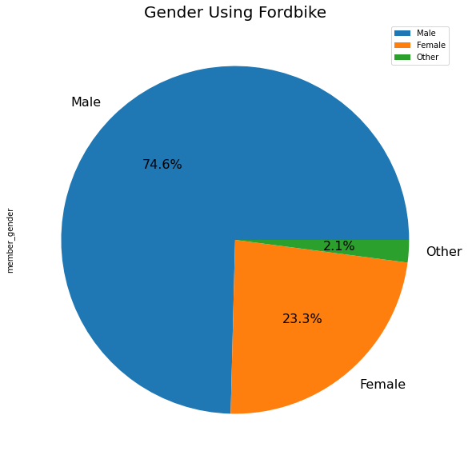

```python
df_gender = df[['member_gender']]
genderPie = df_gender['member_gender'].value_counts()
pieChart = genderPie.plot.pie(figsize=(10,10), autopct='%1.1f%%', fontsize = 16);
pieChart.set_title("Gender Using Fordbike", fontsize = 20);
plt.legend();
```

#### More than two third of the users of Fordbike are males. As a result, marketing campaigns related to males interests could be held.

#### Research Question 2 (What is the ratio of subscribers to customers? )

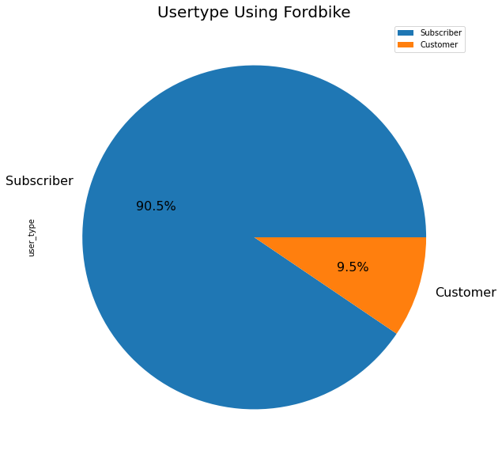

```python
df_user_type = df[['user_type']]
genderPie = df_user_type['user_type'].value_counts()
pieChart = genderPie.plot.pie(figsize=(10,10), autopct='%1.1f%%', fontsize = 16);
pieChart.set_title("Usertype Using Fordbike", fontsize = 20);
plt.legend();
```

#### 90.5 % of the users are subscribers which is an excellent ratio. 9.5% are casual riders who do not ride much often. How could we increaste % of subscribers?

#### Research Question 3 (What is percentage of bikeshare for all the trips? )

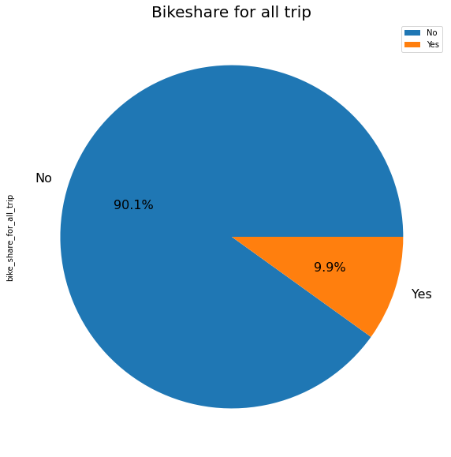

```python
df_bike_share_for_all_trip = df[['bike_share_for_all_trip']]
genderPie = df_bike_share_for_all_trip['bike_share_for_all_trip'].value_counts()
pieChart = genderPie.plot.pie(figsize=(10,10), autopct='%1.1f%%', fontsize = 16);
pieChart.set_title("Bikeshare for all trip", fontsize = 20);
plt.legend();
```

#### 90.1% of the users do not use the bikeshare feautre which is pretty huge.

#### Research Question 4 (What is the range age of riders? )

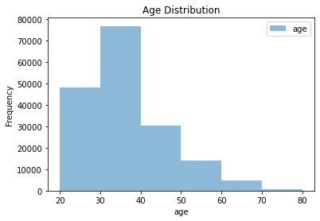

```python
df_age = df[['age','member_gender']]
nowshow_age = df_age.plot.hist(bins=6,range=[20, 80], alpha=0.5, title="Age Distribution")
plt.xlabel('age')
plt.show()
```

#### The most common age using fordbikes services is between 30 and 40 years old which proves that a huge % of the riders are employees and subscribers who ride back and forth to their workplace.

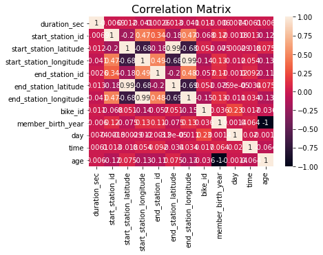

```python
import pandas as pd
import seaborn as sn
import matplotlib.pyplot as plt
corrMatrix = df.corr()
sn.heatmap(corrMatrix, annot=True)
plt.title('Correlation Matrix', fontsize=16);
```

### The correaltion between all paramaters

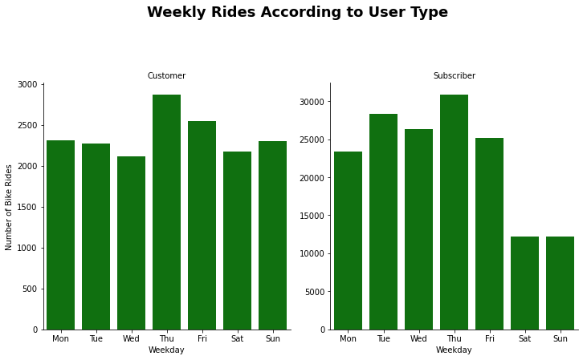

```python
g = sns.catplot(data=df, x='weekday', col="user_type", kind='count', sharey = False, color = 'green', order = weekday)
g.set_axis_labels("Weekday", "Number of Bike Rides")
g.set_titles("{col_name}")
g.fig.suptitle('Weekly Rides According to User Type',y=1.2, fontsize=18, fontweight='bold');
```

### The above graph shows that subscribers use the bike mostly on weekdays to their workplace, however, customers ride the bike on weekends and weekdays almost equally.

[figure not shown]

```python
g = sns.catplot(data=df, x='day', col="user_type", kind='count', sharey = False,color = 'green')
g.fig.set_figwidth(18)
g.fig.set_figheight(5)
g.set_axis_labels("day", "Bike Rides")
g.set_titles("{col_name}")
g.fig.suptitle('Days in Month According to User Type', y=1.2, fontsize=14, fontweight='bold');
```

### Weekends always show a drop in number of bike rides. A disount and free rides should be offered on weekends to encourage users to ride more.

[figure not shown]

```python
g = sns.catplot(data=df, x='time', col="user_type", kind='count', sharey = False, color = 'green')
g.fig.set_figwidth(15)
g.fig.set_figheight(5)
g.set_axis_labels("time", "Bike Rides")
g.set_titles("{col_name}")
g.fig.suptitle('Start Time for Ride According to User Type', y=1.2, fontsize=14, fontweight='bold');
```

### between 12 am and 5 am, number of riders is very limited. As the sun rises and people start to get off to work, number of riders increase gradually.

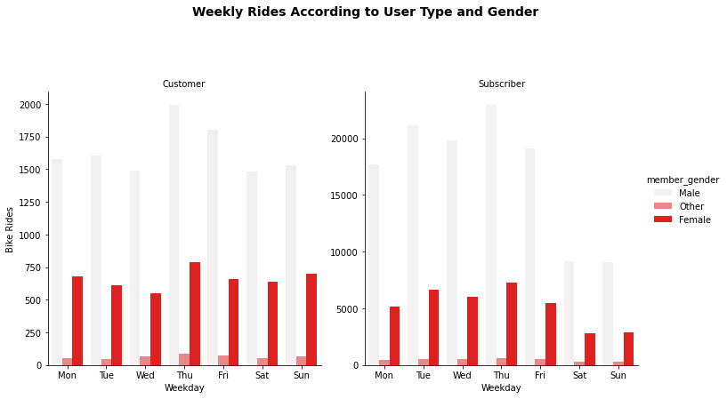

```python
g = sns.catplot(data=df, x='weekday',hue='member_gender' ,col="user_type", kind='count', sharey = False, color = 'red', order = weekday)
g.set_axis_labels("Weekday", "Bike Rides")
g.set_titles("{col_name}")
g.fig.suptitle('Weekly Rides According to User Type and Gender', y=1.2, fontsize=14, fontweight='semibold');
```

#### Male riders are always more than female rider. The trend is almost the same for males and females. Thursday is the best seller day!!

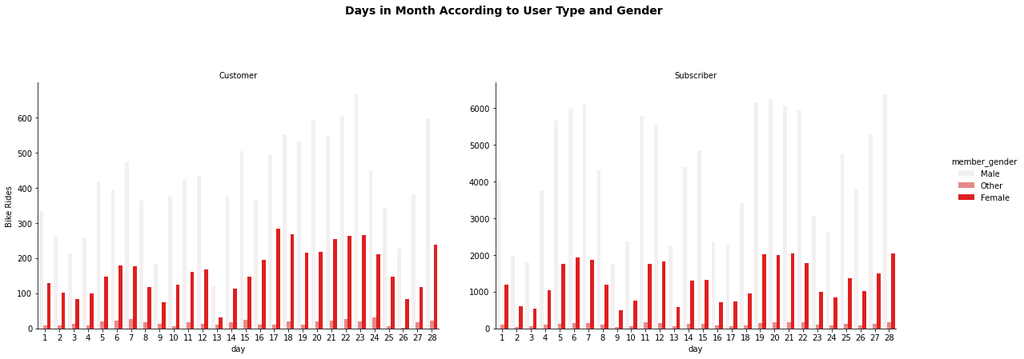

```python
g = sns.catplot(data=df, x='day', hue='member_gender', col="user_type", kind='count', sharey = False, color = 'red')
g.fig.set_figwidth(18)
g.fig.set_figheight(5)
g.set_axis_labels("day", "Bike Rides")
g.set_titles("{col_name}")
g.fig.suptitle('Days in Month According to User Type and Gender', y=1.2, fontsize=14, fontweight='semibold');
```

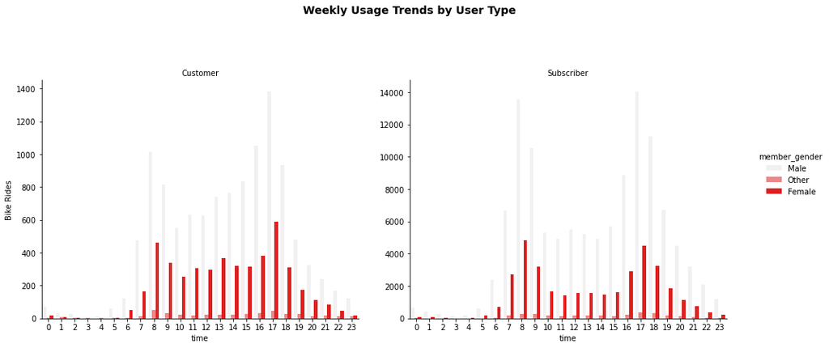

```python
g = sns.catplot(data=df, x='time',hue='member_gender', col="user_type", kind='count', sharey = False, color = 'red')
g.fig.set_figwidth(15)
g.fig.set_figheight(5)
g.set_axis_labels("time", "Bike Rides")
g.set_titles("{col_name}")
g.fig.suptitle('Weekly Usage Trends by User Type', y=1.2, fontsize=14, fontweight='semibold');
```